# Problem Statement

The purpose is to predict whether the Pima Indian women shows signs of diabetes or not. We are using a dataset collected by "National Institute of Diabetes and Digestive and Kidney Diseases" which consists of a number of attributes which would help us to perform this prediction.

**Constraints on data collection**

All patients whose data has been collected are females at least 21 years old of Pima Indian heritage

```python
#Import all the necessary modules
from sklearn.model_selection import train_test_split
import seaborn as sns
import matplotlib.pyplot as plt
from sklearn.tree import DecisionTreeClassifier
from sklearn.feature_extraction.text import CountVectorizer
from sklearn import metrics
from sklearn.metrics import accuracy_score, confusion_matrix, recall_score, precision_score, f1_score, auc
from sklearn.ensemble import BaggingClassifier
from sklearn.linear_model import LogisticRegression
from sklearn.ensemble import RandomForestClassifier
from sklearn.ensemble import AdaBoostClassifier
```

# Q1. Load the PIMA Indian Diabetes file into Python DataFrame.

The file can be accessed directly from the URL (https://archive.ics.uci.edu/ml/machine-learning-databases/pima-indians-diabetes/pima-indians-diabetes.data or you may first download it to a local folder and then load it into Python dataframe. Let us assume the data frame is named pima_df

```python
import pandas as pd
import random as rand
import numpy as np
data = pd.read_csv("pima-indians-diabetes-2.data", names=["Pregnancies", "Glucose", "BloodPressure", "SkinThickness","Insulin","BMI","DiabetesPedigreeF","Age","Outcome"])
data.head()
```

|  | Pregnancies | Glucose | BloodPressure | SkinThickness | Insulin | BMI | DiabetesPedigreeF | Age | Outcome |
| --- | --- | --- | --- | --- | --- | --- | --- | --- | --- |
| 0 | 6 | 148 | 72 | 35 | 0 | 33.6 | 0.627 | 50 | 1 |
| 1 | 1 | 85 | 66 | 29 | 0 | 26.6 | 0.351 | 31 | 0 |
| 2 | 8 | 183 | 64 | 0 | 0 | 23.3 | 0.672 | 32 | 1 |
| 3 | 1 | 89 | 66 | 23 | 94 | 28.1 | 0.167 | 21 | 0 |
| 4 | 0 | 137 | 40 | 35 | 168 | 43.1 | 2.288 | 33 | 1 |

It is always a good practice to eye-ball raw data to get a feel of the data in terms of number of structure of the file, number of attributes, types of attributes and a general idea of likely challenges in the dataset. You would notice that it is a comma separated file. There are no column names!. Check the associated folders and find out about each attribute the name. What information is available about the data.

# Q2. Print 10 samples from the dataset

```python
data.sample(10)
```

|  | Pregnancies | Glucose | BloodPressure | SkinThickness | Insulin | BMI | DiabetesPedigreeF | Age | Outcome |
| --- | --- | --- | --- | --- | --- | --- | --- | --- | --- |
| 721 | 1 | 114 | 66 | 36 | 200 | 38.1 | 0.289 | 21 | 0 |
| 247 | 0 | 165 | 90 | 33 | 680 | 52.3 | 0.427 | 23 | 0 |
| 360 | 5 | 189 | 64 | 33 | 325 | 31.2 | 0.583 | 29 | 1 |
| 435 | 0 | 141 | 0 | 0 | 0 | 42.4 | 0.205 | 29 | 1 |
| 656 | 2 | 101 | 58 | 35 | 90 | 21.8 | 0.155 | 22 | 0 |
| 270 | 10 | 101 | 86 | 37 | 0 | 45.6 | 1.136 | 38 | 1 |
| 550 | 1 | 116 | 70 | 28 | 0 | 27.4 | 0.204 | 21 | 0 |
| 182 | 1 | 0 | 74 | 20 | 23 | 27.7 | 0.299 | 21 | 0 |
| 604 | 4 | 183 | 0 | 0 | 0 | 28.4 | 0.212 | 36 | 1 |
| 602 | 1 | 124 | 74 | 36 | 0 | 27.8 | 0.100 | 30 | 0 |

# Q3 Print the datatypes of each column and the shape of the dataset

```python
print("datatype_from_info_function")
print(data.info())
print("\n")
print("shape of dataset")
print(data.shape)
```

```
datatype_from_info_function
<class 'pandas.core.frame.DataFrame'>
RangeIndex: 768 entries, 0 to 767
Data columns (total 9 columns):
Pregnancies          768 non-null int64
Glucose              768 non-null int64
BloodPressure        768 non-null int64
SkinThickness        768 non-null int64
Insulin              768 non-null int64
BMI                  768 non-null float64
DiabetesPedigreeF    768 non-null float64
Age                  768 non-null int64
Outcome              768 non-null int64
dtypes: float64(2), int64(7)
memory usage: 54.1 KB
None


shape of dataset
(768, 9)
```

There are '0's in the data. Are they really valid '0's or they are missing values? Plasma, BP, skin thickness etc. these values cannot be 0. look at column by column logically to understand this.

# Q4 Replace all the 0s in the column with the median of the same column value accordingly.

```python
df = data
a = data.median()
a
```

[output not shown]

```python
df.replace(0,a, inplace = True)
df.head(20)
```

|  | Pregnancies | Glucose | BloodPressure | SkinThickness | Insulin | BMI | DiabetesPedigreeF | Age | Outcome |
| --- | --- | --- | --- | --- | --- | --- | --- | --- | --- |
| 0 | 6 | 148 | 72 | 35 | 30.5 | 33.6 | 0.627 | 50 | 1 |
| 1 | 1 | 85 | 66 | 29 | 30.5 | 26.6 | 0.351 | 31 | 0 |
| 2 | 8 | 183 | 64 | 23 | 30.5 | 23.3 | 0.672 | 32 | 1 |
| 3 | 1 | 89 | 66 | 23 | 94.0 | 28.1 | 0.167 | 21 | 0 |
| 4 | 3 | 137 | 40 | 35 | 168.0 | 43.1 | 2.288 | 33 | 1 |
| 5 | 5 | 116 | 74 | 23 | 30.5 | 25.6 | 0.201 | 30 | 0 |
| 6 | 3 | 78 | 50 | 32 | 88.0 | 31.0 | 0.248 | 26 | 1 |
| 7 | 10 | 115 | 72 | 23 | 30.5 | 35.3 | 0.134 | 29 | 0 |
| 8 | 2 | 197 | 70 | 45 | 543.0 | 30.5 | 0.158 | 53 | 1 |
| 9 | 8 | 125 | 96 | 23 | 30.5 | 32.0 | 0.232 | 54 | 1 |
| 10 | 4 | 110 | 92 | 23 | 30.5 | 37.6 | 0.191 | 30 | 0 |
| 11 | 10 | 168 | 74 | 23 | 30.5 | 38.0 | 0.537 | 34 | 1 |
| 12 | 10 | 139 | 80 | 23 | 30.5 | 27.1 | 1.441 | 57 | 0 |
| 13 | 1 | 189 | 60 | 23 | 846.0 | 30.1 | 0.398 | 59 | 1 |
| 14 | 5 | 166 | 72 | 19 | 175.0 | 25.8 | 0.587 | 51 | 1 |
| 15 | 7 | 100 | 72 | 23 | 30.5 | 30.0 | 0.484 | 32 | 1 |
| 16 | 3 | 118 | 84 | 47 | 230.0 | 45.8 | 0.551 | 31 | 1 |
| 17 | 7 | 107 | 74 | 23 | 30.5 | 29.6 | 0.254 | 31 | 1 |
| 18 | 1 | 103 | 30 | 38 | 83.0 | 43.3 | 0.183 | 33 | 0 |
| 19 | 1 | 115 | 70 | 30 | 96.0 | 34.6 | 0.529 | 32 | 1 |

# Q5 Print the descriptive statistics of each & every column using describe() function

```python
data.describe()
```

|  | Pregnancies | Glucose | BloodPressure | SkinThickness | Insulin | BMI | DiabetesPedigreeF | Age | Outcome |
| --- | --- | --- | --- | --- | --- | --- | --- | --- | --- |
| count | 768.000000 | 768.000000 | 768.000000 | 768.000000 | 768.000000 | 768.000000 | 768.000000 | 768.000000 | 768.000000 |
| mean | 4.278646 | 121.656250 | 72.386719 | 27.334635 | 94.652344 | 32.450911 | 0.471876 | 33.240885 | 0.348958 |
| std | 3.021516 | 30.438286 | 12.096642 | 9.229014 | 105.547598 | 6.875366 | 0.331329 | 11.760232 | 0.476951 |
| min | 1.000000 | 44.000000 | 24.000000 | 7.000000 | 14.000000 | 18.200000 | 0.078000 | 21.000000 | 0.000000 |
| 25% | 2.000000 | 99.750000 | 64.000000 | 23.000000 | 30.500000 | 27.500000 | 0.243750 | 24.000000 | 0.000000 |
| 50% | 3.000000 | 117.000000 | 72.000000 | 23.000000 | 31.250000 | 32.000000 | 0.372500 | 29.000000 | 0.000000 |
| 75% | 6.000000 | 140.250000 | 80.000000 | 32.000000 | 127.250000 | 36.600000 | 0.626250 | 41.000000 | 1.000000 |
| max | 17.000000 | 199.000000 | 122.000000 | 99.000000 | 846.000000 | 67.100000 | 2.420000 | 81.000000 | 1.000000 |

# Q6 See the distribution of 'Class' variable and plot it using appropriate graph.

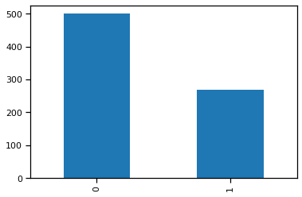

```python
import seaborn as sns
import matplotlib.pyplot as plt
data['Outcome'].value_counts().plot(kind='bar')
```

# Just for your understanding - Using univariate analysis check the individual attributes for their basic statistic such as central values, spread, tails etc. What are your observations (any two attributes). Its an optional step and will not be graded.

# Q7. Use pairplots and correlation method to observe the relationship between different variables and state your insights.

Hint: Use seaborn plot and check the relationship between different variables

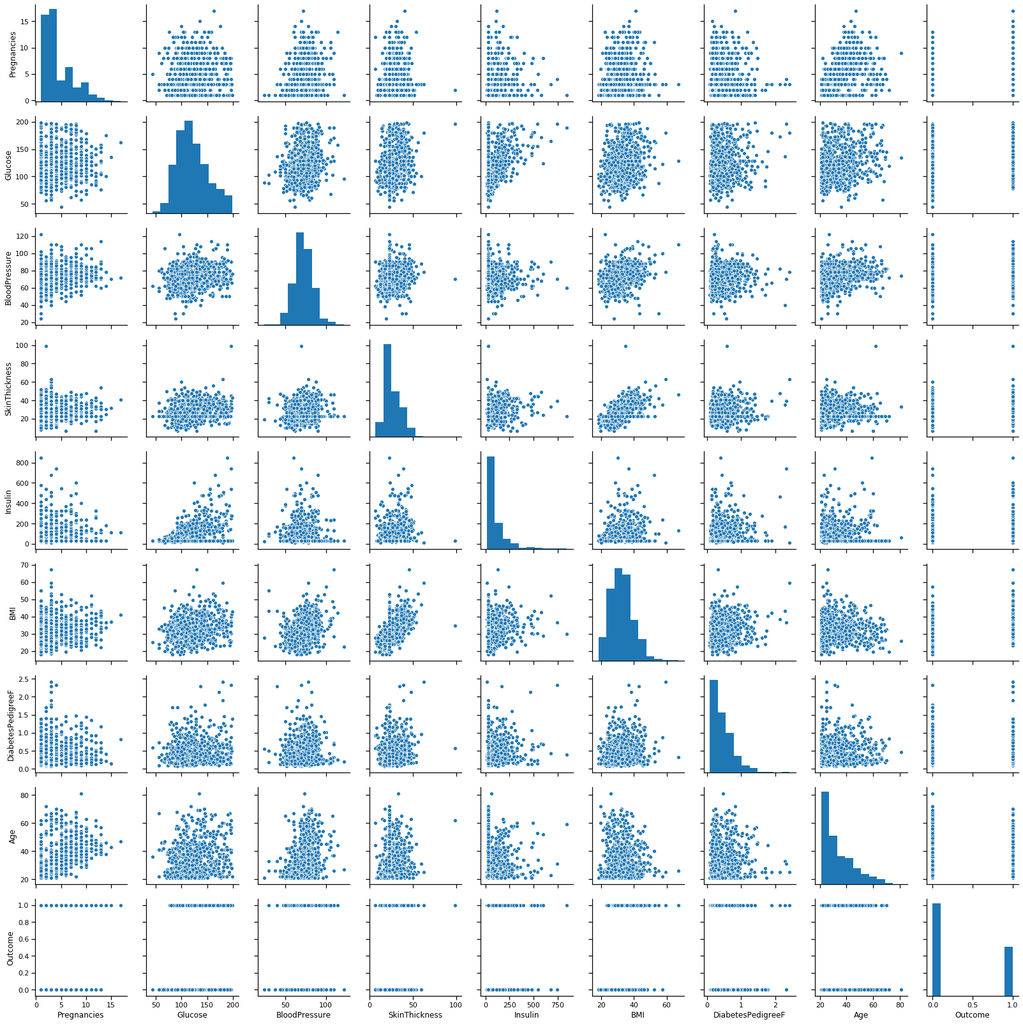

```python
sns.pairplot(data)
```

```python
data.corr()
#using this graph and correlation function - we are having some insights

good coorelation
1- Pregnancies & age have good coorelation
2- SkinThickness & BMI have good coorelation
3- Outcome & Glucose have good coorelation


Bad coorelation
Pregnancies with SkinThickness & Insulin & BMI & DiabetesPedigreeF
BloodPressure with Insulin & DiabetesPedigreeF
age with BMI & Insulin & SkinThickness & DiabetesPedigreeF
```

|  | Pregnancies | Glucose | BloodPressure | SkinThickness | Insulin | BMI | DiabetesPedigreeF | Age | Outcome |
| --- | --- | --- | --- | --- | --- | --- | --- | --- | --- |
| Pregnancies | 1.000000 | 0.149326 | 0.247530 | 0.060706 | -0.059580 | 0.080540 | -0.016151 | 0.538169 | 0.245466 |
| Glucose | 0.149326 | 1.000000 | 0.218937 | 0.172143 | 0.357573 | 0.231400 | 0.137327 | 0.266909 | 0.492782 |
| BloodPressure | 0.247530 | 0.218937 | 1.000000 | 0.147809 | -0.028721 | 0.281132 | -0.002378 | 0.324915 | 0.165723 |
| SkinThickness | 0.060706 | 0.172143 | 0.147809 | 1.000000 | 0.238188 | 0.546951 | 0.142977 | 0.054514 | 0.189065 |
| Insulin | -0.059580 | 0.357573 | -0.028721 | 0.238188 | 1.000000 | 0.189022 | 0.178029 | -0.015413 | 0.148457 |
| BMI | 0.080540 | 0.231400 | 0.281132 | 0.546951 | 0.189022 | 1.000000 | 0.153506 | 0.025744 | 0.312249 |
| DiabetesPedigreeF | -0.016151 | 0.137327 | -0.002378 | 0.142977 | 0.178029 | 0.153506 | 1.000000 | 0.033561 | 0.173844 |
| Age | 0.538169 | 0.266909 | 0.324915 | 0.054514 | -0.015413 | 0.025744 | 0.033561 | 1.000000 | 0.238356 |
| Outcome | 0.245466 | 0.492782 | 0.165723 | 0.189065 | 0.148457 | 0.312249 | 0.173844 | 0.238356 | 1.000000 |

Using the plot - infer the relationship between different variables

# Q8 Split the pima_df into training and test set in the ratio of 70:30 (Training:Test).</b>

```python
X = data.drop(labels = "Outcome", axis = 1)
y = data["Outcome"]
test_size = .30
sead = 7
X_train, X_test, y_train, y_test = train_test_split(X,y,test_size = test_size,random_state = sead)
print(X_train.shape)
print(X_test.shape)
```

```
(537, 8)
(231, 8)
```

# Q9 Create the decision tree model using “entropy” method of reducing the entropy and fit it to training data.</b>

```python
dt_model = DecisionTreeClassifier(criterion = 'entropy', max_depth = 5, min_samples_leaf=5 )
print(dt_model.fit(X_train, y_train))
print(dt_model.score(X_train , y_train))
print(dt_model.score(X_test , y_test))
```

```
DecisionTreeClassifier(class_weight=None, criterion='entropy', max_depth=5,
                       max_features=None, max_leaf_nodes=None,
                       min_impurity_decrease=0.0, min_impurity_split=None,
                       min_samples_leaf=5, min_samples_split=2,
                       min_weight_fraction_leaf=0.0, presort=False,
                       random_state=None, splitter='best')
0.8230912476722533
0.7142857142857143
```

```python
dt_model = DecisionTreeClassifier(criterion = 'entropy', max_depth = 5, min_samples_leaf=5 )
print(dt_model.fit(X_train, y_train))
print(dt_model.score(X_train , y_train))
print(dt_model.score(X_test , y_test))
```

```
DecisionTreeClassifier(class_weight=None, criterion='entropy', max_depth=5,
                       max_features=None, max_leaf_nodes=None,
                       min_impurity_decrease=0.0, min_impurity_split=None,
                       min_samples_leaf=5, min_samples_split=2,
                       min_weight_fraction_leaf=0.0, presort=False,
                       random_state=None, splitter='best')
0.8230912476722533
0.7142857142857143
```

# Q10 Print the accuracy of the model & print the confusion matrix

```python
print("Train Accuracy", dt_model.score(X_train , y_train))
print("Test Accuracy", dt_model.score(X_test , y_test))
y_predict_train = dt_model.predict(X_train)
y_predict_test = dt_model.predict(X_test)
print(metrics.confusion_matrix(y_train, y_predict_train))
print("\n")
print(metrics.confusion_matrix(y_test, y_predict_test))
```

[output not shown]

Print the feature importance of the decision model - Optional

```python
dt_model = DecisionTreeClassifier(criterion = 'entropy', max_depth = 5, min_samples_leaf=60 )
print(dt_model.fit(X_train, y_train))
print(dt_model.score(X_train , y_train))
print(dt_model.score(X_test , y_test))
dt_model = DecisionTreeClassifier(criterion = 'entropy') #without any hyper parameter
print(dt_model.fit(X_train, y_train))
print(dt_model.score(X_train , y_train))
print(dt_model.score(X_test , y_test))
```

```
DecisionTreeClassifier(class_weight=None, criterion='entropy', max_depth=5,
                       max_features=None, max_leaf_nodes=None,
                       min_impurity_decrease=0.0, min_impurity_split=None,
                       min_samples_leaf=60, min_samples_split=2,
                       min_weight_fraction_leaf=0.0, presort=False,
                       random_state=None, splitter='best')
0.7728119180633147
0.7575757575757576
DecisionTreeClassifier(class_weight=None, criterion='entropy', max_depth=None,
                       max_features=None, max_leaf_nodes=None,
                       min_impurity_decrease=0.0, min_impurity_split=None,
                       min_samples_leaf=1, min_samples_split=2,
                       min_weight_fraction_leaf=0.0, presort=False,
                       random_state=None, splitter='best')
1.0
0.7186147186147186
```

# Q11 Apply the Random forest model and print the accuracy of Random forest Model

```python
rfcl = RandomForestClassifier(n_estimators = 100)
rfcl = rfcl.fit(X_train, y_train)
print(rfcl.score(X_train, y_train))
print(rfcl.score(X_test, y_test))
print("Adding some hyper parameter")
rfcl = RandomForestClassifier(n_estimators = 100, max_depth=5)
rfcl = rfcl.fit(X_train, y_train)
print(rfcl.score(X_train, y_train))
print(rfcl.score(X_test, y_test))
```

```
1.0
0.7532467532467533
Adding some hyper parameter
0.8621973929236499
0.7402597402597403
```

```python
print("Adding more hyper parameter")
rfcl = RandomForestClassifier(n_estimators = 100, max_depth=5, max_features=0.25, max_leaf_nodes=20)
rfcl = rfcl.fit(X_train, y_train)
print(rfcl.score(X_train, y_train))
print(rfcl.score(X_test, y_test))
```

```
Adding more hyper parameter
0.8528864059590316
0.7532467532467533
```

# Q12 Apply Adaboost Ensemble Algorithm for the same data and print the accuracy.

```python
dt_model = DecisionTreeClassifier(criterion = 'entropy', max_depth = 5, min_samples_leaf=5 )
abcl = AdaBoostClassifier(base_estimator=dt_model, n_estimators=50)
abcl = abcl.fit(X_train, y_train)
print(abcl.score(X_train, y_train))
abcl.score(X_test , y_test)
```

```
1.0
```

```
0.7229437229437229
```

```python
dt_model = DecisionTreeClassifier(criterion = 'entropy', max_depth = 2, min_samples_leaf=5 )
abcl = AdaBoostClassifier(base_estimator=dt_model, n_estimators=10)
print("Changing some hyper parameters like maxdepth and n_estimators will give us better results")
abcl = abcl.fit(X_train, y_train)
print(abcl.score(X_train, y_train))
abcl.score(X_test , y_test)
```

```
Changing some hyper parameters like maxdepth and n_estimators will give us better results
0.8435754189944135
```

```
0.7359307359307359
```

# Q13 - Apply Bagging Classifier Algorithm and print the accuracy.

```python
lrModel = LogisticRegression()
dt_model = DecisionTreeClassifier(criterion = 'entropy', max_depth = 5, min_samples_leaf=5 )
bgcl = BaggingClassifier(n_estimators=50)
bgcl = bgcl.fit(X_train, y_train)
print(bgcl.score(X_train , y_train))
print(bgcl.score(X_test , y_test))
print("decision tree as base_estimator")
bgcl = BaggingClassifier(base_estimator=dt_model, n_estimators=50)
bgcl = bgcl.fit(X_train, y_train)
print(bgcl.score(X_train , y_train))
print(bgcl.score(X_test , y_test))
```

```
1.0
0.7619047619047619
decision tree as base_estimator
0.8491620111731844
0.7575757575757576
```

```python
bgcl = BaggingClassifier(base_estimator=lrModel, n_estimators=50)
bgcl = bgcl.fit(X_train, y_train)
print(bgcl.score(X_train , y_train))
print(bgcl.score(X_test , y_test))
```

[output not shown]

[output cut: 33 more lines]

[output not shown]

```
0.7653631284916201
0.7792207792207793
```

[output not shown]

# Q14 - Apply GradientBoost Classifier Algorithm for the same data and print the accuracy

```python
from sklearn.ensemble import GradientBoostingClassifier
gbcl = GradientBoostingClassifier(n_estimators = 50, learning_rate = 0.09, max_depth=5)
gbcl = gbcl.fit(X_train, y_train)
print(gbcl.score(X_train , y_train))
gbcl.score(X_test, y_test)
```

```
0.9795158286778398
```

```
0.7402597402597403
```

```python
gbcl = GradientBoostingClassifier(n_estimators = 30, learning_rate = 0.09, max_depth=2)
print("Changing some hyper parameters like maxdepth and n_estimators will give us better results")
gbcl = gbcl.fit(X_train, y_train)
print(gbcl.score(X_train , y_train))
gbcl.score(X_test, y_test)
```

```
Changing some hyper parameters like maxdepth and n_estimators will give us better results
0.819366852886406
```

```
0.7575757575757576
```